# Linear Regression - Project Exercise

**Importing pandas, numpy, matplotlib,and seaborn.**

```python
import pandas as pd
import numpy as np
import matplotlib.pyplot as plt
import seaborn as sns
% matplotlib inline
```

## Get the Data

**Reading the Ecommerce Customers csv file as a DataFrame called customers.**

```python
customers = pd.read_csv("Ecommerce Customers")
```

**Checking the head ,info(), describe() of customers.**

```python
customers.info()
```

```
<class 'pandas.core.frame.DataFrame'>
RangeIndex: 500 entries, 0 to 499
Data columns (total 8 columns):
Email                   500 non-null object
Address                 500 non-null object
Avatar                  500 non-null object
Avg. Session Length     500 non-null float64
Time on App             500 non-null float64
Time on Website         500 non-null float64
Length of Membership    500 non-null float64
Yearly Amount Spent     500 non-null float64
dtypes: float64(5), object(3)
memory usage: 31.3+ KB
```

```python
customers.describe()
```

|  | Avg. Session Length | Time on App | Time on Website | Length of Membership | Yearly Amount Spent |
| --- | --- | --- | --- | --- | --- |
| count | 500.000000 | 500.000000 | 500.000000 | 500.000000 | 500.000000 |
| mean | 33.053194 | 12.052488 | 37.060445 | 3.533462 | 499.314038 |
| std | 0.992563 | 0.994216 | 1.010489 | 0.999278 | 79.314782 |
| min | 29.532429 | 8.508152 | 33.913847 | 0.269901 | 256.670582 |
| 25% | 32.341822 | 11.388153 | 36.349257 | 2.930450 | 445.038277 |
| 50% | 33.082008 | 11.983231 | 37.069367 | 3.533975 | 498.887875 |
| 75% | 33.711985 | 12.753850 | 37.716432 | 4.126502 | 549.313828 |
| max | 36.139662 | 15.126994 | 40.005182 | 6.922689 | 765.518462 |

```python
customers.head()
```

|  | Email | Address | Avatar | Avg. Session Length | Time on App | Time on Website | Length of Membership | Yearly Amount Spent |
| --- | --- | --- | --- | --- | --- | --- | --- | --- |
| 0 | mstephenson@fernandez.com | 835 Frank Tunnel\nWrightmouth, MI 82180-9605 | Violet | 34.497268 | 12.655651 | 39.577668 | 4.082621 | 587.951054 |
| 1 | hduke@hotmail.com | 4547 Archer Common\nDiazchester, CA 06566-8576 | DarkGreen | 31.926272 | 11.109461 | 37.268959 | 2.664034 | 392.204933 |
| 2 | pallen@yahoo.com | 24645 Valerie Unions Suite 582\nCobbborough, D... | Bisque | 33.000915 | 11.330278 | 37.110597 | 4.104543 | 487.547505 |
| 3 | riverarebecca@gmail.com | 1414 David Throughway\nPort Jason, OH 22070-1220 | SaddleBrown | 34.305557 | 13.717514 | 36.721283 | 3.120179 | 581.852344 |
| 4 | mstephens@davidson-herman.com | 14023 Rodriguez Passage\nPort Jacobville, PR 3... | MediumAquaMarine | 33.330673 | 12.795189 | 37.536653 | 4.446308 | 599.406092 |

## Exploratory Data Analysis

**Using seaborn to create a jointplot to compare the Time on Website and Yearly Amount Spent columns.**

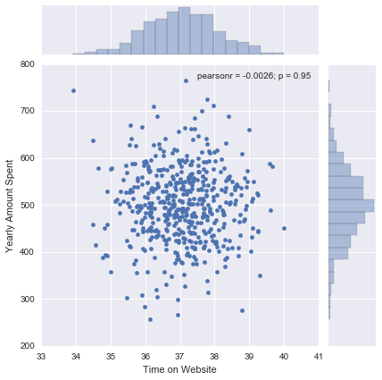

```python
sns.jointplot("Time on Website", "Yearly Amount Spent", data = customers )
```

**Doing the same with the Time on App column.**

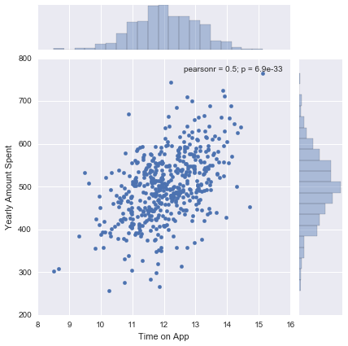

```python
sns.jointplot("Time on App", "Yearly Amount Spent", data = customers )
```

**Using jointplot to create a 2D hex bin plot comparing Time on App and Length of Membership.**

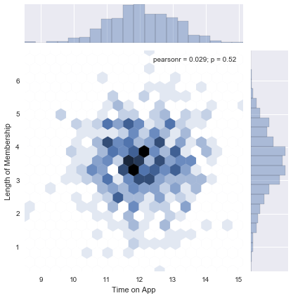

```python
sns.jointplot("Time on App", "Length of Membership", data=customers, kind="hex")
```

**Using pairplot for EDA**

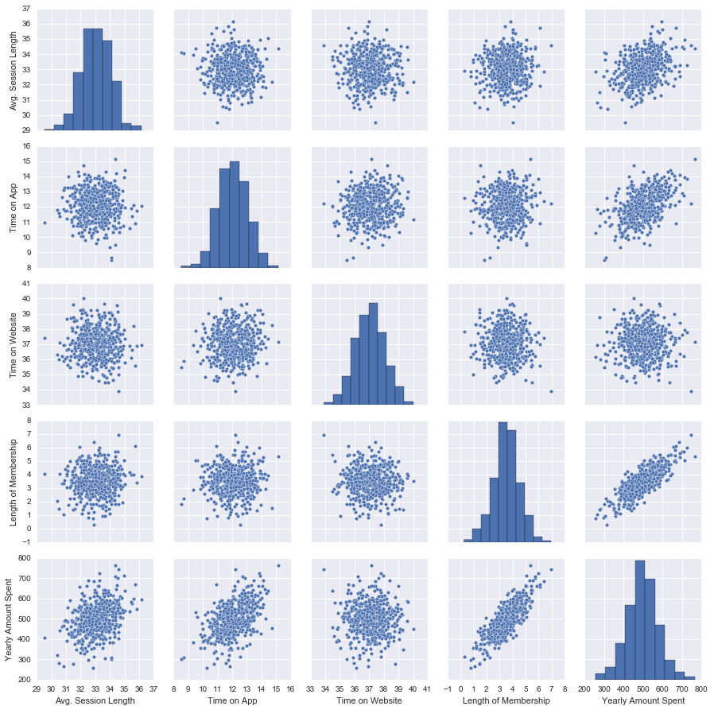

```python
sns.pairplot(customers)
```

length of membership looks the most correlated feature with Yearly Amount Spent

**Creating a linear model plot of Yearly Amount Spent vs. Length of Membership.**

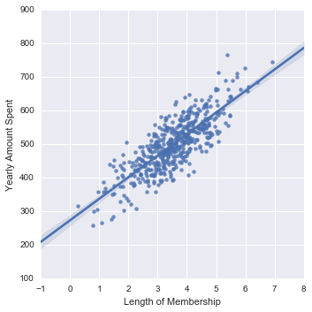

```python
sns.lmplot("Length of Membership", "Yearly Amount Spent", data= customers )
```

## Training and Testing Data

```python
customers.columns
```

```
Index([u'Email', u'Address', u'Avatar', u'Avg. Session Length', u'Time on App',
       u'Time on Website', u'Length of Membership', u'Yearly Amount Spent'],
      dtype='object')
```

```python
X = customers[["Avg. Session Length", "Time on App", "Time on Website", "Length of Membership"]]
```

```python
y = customers["Yearly Amount Spent"]
```

```python
from sklearn.cross_validation import train_test_split
```

```python
X_train, X_test, y_train, y_test = train_test_split(X, y, test_size=0.3, random_state=101)
```

## Training the Model

**Importing LinearRegression from sklearn.linear_model**

```python
from sklearn.linear_model import LinearRegression
```

**Creating an instance of a LinearRegression() model named lm.**

```python
lm = LinearRegression()
```

**Train/fit lm on the training data.**

```python
lm.fit(X_train, y_train)
```

```
LinearRegression(copy_X=True, fit_intercept=True, n_jobs=1, normalize=False)
```

**Printing out the coefficients of the model**

```python
lm.intercept_
```

```
-1047.9327822502387
```

```python
lm.coef_
```

```
array([ 25.98154972,  38.59015875,   0.19040528,  61.27909654])
```

Interpreting the coefficients:

- Holding all other features fixed, a 1 unit increase in **Avg. Session Length** is associated with an **increase of 25.98 total dollars spent**.
- Holding all other features fixed, a 1 unit increase in **Time on App** is associated with an **increase of 38.59 total dollars spent**.
- Holding all other features fixed, a 1 unit increase in **Time on Website** is associated with an **increase of 0.19 total dollars spent**.
- Holding all other features fixed, a 1 unit increase in **Length of Membership** is associated with an **increase of 61.27 total dollars spent**.

## Predicting Test Data

**Using lm.predict() to predict off the X_test set of the data.**

```python
prediction = lm.predict(X_test)
```

**Creating a scatterplot of the real test values versus the predicted values.**

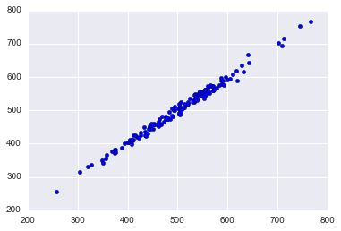

```python
plt.scatter(y_test, prediction)
```

## Evaluating the Model

Let's evaluate the model performance by calculating the residual sum of squares and the explained variance score (R^2).

```python
from sklearn import metrics
```

```python
print("MAE:", metrics.mean_absolute_error(y_test, prediction))
print("MSE:", metrics.mean_squared_error(y_test, prediction))
print("RMSE:", np.sqrt(metrics.mean_squared_error(y_test, prediction)))
print("R-squared-value:", metrics.r2_score(y_test, prediction))
```

```
('MAE:', 7.2281486534308534)
('MSE:', 79.81305165097487)
('RMSE:', 8.9338150669786565)
('R-squared-value:', 0.98900462467412331)
```

## Residuals

**Plotting a histogram of the residuals to make sure it looks normally distributed.**

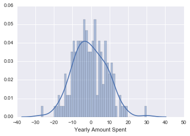

```python
sns.distplot(y_test-prediction, bins = 50)
```